# Introduction to R programming for data science – day 1

Medical University of Innsbruck, Austria

## R programming

R is:

- One of the leading programming languages for statistics and data science
- Useful for basic and advanced data analyses
- Prerequisite for job positions in the life sciences

Why?

- Its is free
- It supports reproducible analysis
- It provides packages for data analysis

## In this course

We will learn the **basics of R programming** through lectures and hands-on computer exercises using Rstudio:

- variables, data types, and data structures
- data manipulation and visualization
- operations
- reading and writing files
- running and repeating tasks using functions and control statements.

Disclaimer: this is **not** a course in statistics or bioinformatics.

## Course info

**Course material and info**: https://github.com/FFinotello/Rcourse

**Note**: to download a text file, right-click on “Raw” and select “Save link as”.

**Evaluation**: based on a data analysis project to be described in a short report and sent by e-mail.

**How to ask questions**

- Chat
- [Collaborative Google Doc](https://docs.google.com/document/d/1XMRyRu4VAb1kXgstZc61qrt0gKggWX5A5OYXpGZI2P8/edit)
- E-mail

## Installation

Install first R and then Rstudio

To install **R** (version ≥ 4):

https://www.r-project.org

See “To download R, please choose your preferred CRAN mirror”.

To install **RStudio Desktop**:

https://www.rstudio.com/products/rstudio/download/#download

## RStudio

## RStudio console

RStudio is an integrated development environment (IDE) for R.  
It has four main panels with adjustable sizes:

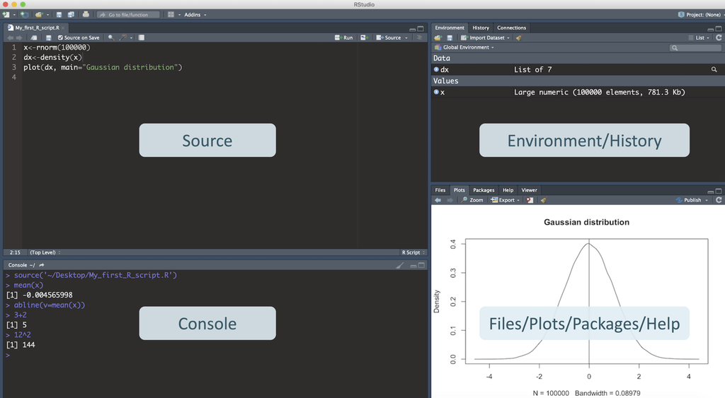

From the toolbar: View > Panes > Show All Panes

## The RStudio console

In the console you can type commands and see outputs.

```r
( 12^2 - 20 * 2 + 1) / 5
```

```
## [1] 21
```

```r
log10(100) - sqrt(9) / 3
```

```
## [1] 1
```

```r
# Any text preceded by a hashtag is not evaluated (= comment!)
```

## Variables and data types

## Variables

**Variables**: symbolic names used to store data that can be manipulated in a computer program

In R, variables are assigned with <-

```r
height <- 1.90

weight <- 80
```

## Variable names

- *Should* be short but descriptive
- *Must* start with a letter
- *Must not* contain special characters
- *Cannot* be reserved words

**Reserved words**: words with special meaning in R that cannot be used as identifiers. Examples: if, break, Inf, TRUE

👍 *cellFrac*, *cell_frac*, *cell.frac*, *cellfrac_1*

👎 *cell-frac*, *1cellfrac*, *TRUE*

```r
(T <- 5 * 2 )
```

```
## [1] 10
```

## Case-sensitive programming

R is case-sensitive

```r
# Body mass index (BMI)
# defined as: weight/height^2
BMI <- 80/1.90^2

BMI
```

```
## [1] 22.16066
```

```r
bmi
```

```
## Error in eval(expr, envir, enclos): object 'bmi' not found
```

## Operations

Once variables are assigned, they can be used to perform operations

```r
height <- 1.90
weight <- 80
( BMI <- weight/height^2 )
```

```
## [1] 22.16066
```

```r
x <- 6
y <- 2
x <- 4
x + y
```

```
## [1] 6
```

## Arithmetic operators

| Operator | Description |
| --- | --- |
| + | Addition |
| - | Subtraction |
| * | Multiplication |
| / | Division |
| ^ | Exponent |
| %% | Modulus (remainder from division) |
| %/% | Integer Division |

## Relational operators

| Operator | Description |
| --- | --- |
| < | Less than |
| > | Greater than |
| <= | Less than or equal to |
| >= | Greater than or equal to |
| == | Equal to |
| != | Not equal to |

## Logical operators

| Operator | Description |
| --- | --- |
| ! | Logical NOT |
| & | Element-wise logical AND |
| && | Logical AND |
| \| | Element-wise logical OR |
| \|\| | Logical OR |

## Atomic vector types

In R, there are several types of atomic vectors (also called *classes*):

- **Numeric**
- **Character**
- **Logical**
- Complex
- Integer

## Data type examples

```r
Name <- "Maria"
class(Name)
```

```
## [1] "character"
```

```r
PhD <- TRUE
class(PhD)
```

```
## [1] "logical"
```

```r
yearsSincePhD <- 5
class(yearsSincePhD)
```

```
## [1] "numeric"
```

## Missing values

In R, missing values are usually coded with NA

```r
Name <- "Michael"
PhD <- FALSE
yearsSincePhD <- NA

is.na(Name)
```

```
## [1] FALSE
```

```r
is.na(yearsSincePhD)
```

```
## [1] TRUE
```

Note: NA are not strings (no quotation marks)

## Other indefinite values

Not a number: NaN

```r
var1 <- 0/0
var1
```

```
## [1] NaN
```

Infinite: Inf

```r
( var2 <- 9/0 )
```

```
## [1] Inf
```

```r
( var3 <- -10/0 )
```

```
## [1] -Inf
```

## Data conversion/coercion

Class conversion is possible, but it must be handled with care

```r
var1 <- 1
( var2 <- as.character(var1) )
```

```
## [1] "1"
```

```r
class(var2)
```

```
## [1] "character"
```

```r
( var3 <- as.logical(var1) )
```

```
## [1] TRUE
```

## Data type conversion

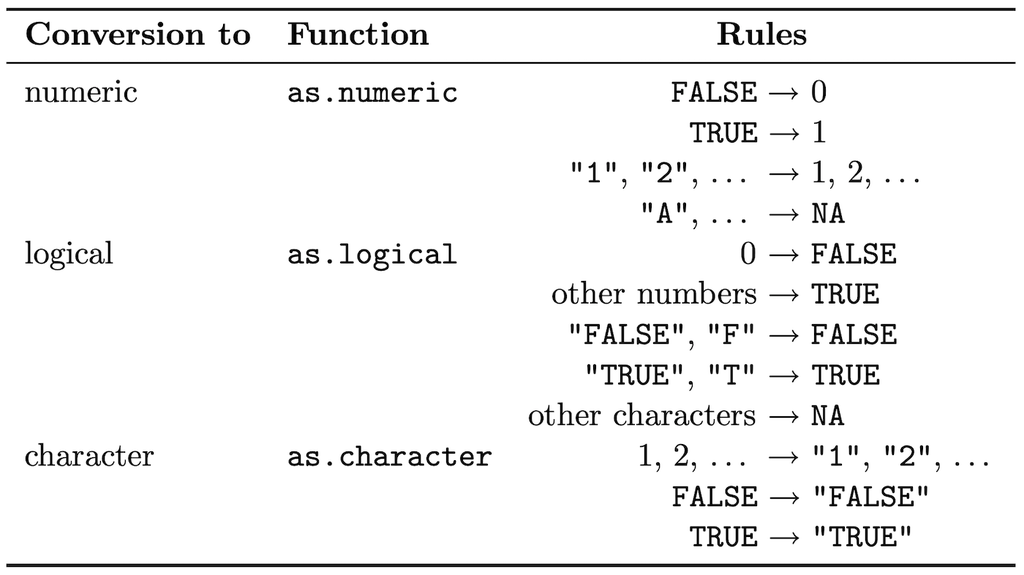

Source: https://cran.r-project.org/doc/contrib/Paradis-rdebuts_en.pdf

## Data structures

## Data structures

In R, there are different **data structures**, including:

| Data structure | Can contain different data types? |
| --- | --- |
| Vector | No |
| Matrix | No |
| Factor | No |
| List | Yes |
| Data.frame | Yes |

## Data structure: vector

**Vectors** can be build with the *c* function and their length can be assessed with the *length* function

```r
( x <- c(1, 2, 3, 4) )
```

```
## [1] 1 2 3 4
```

```r
( y <- c("a", "b", "c") )
```

```
## [1] "a" "b" "c"
```

```r
length(y)
```

```
## [1] 3
```

## Vectors and data types

Vectors can contain a single data type only, so beware of conversions

```r
( z <- c("a", "b", 1, 2) )
```

```
## [1] "a" "b" "1" "2"
```

```r
( v <- c(x, y) )
```

```
## [1] "1" "2" "3" "4" "a" "b" "c"
```

What are the classes of *z* and *v*?

## Creating numeric vectors

```r
j <- 1:4  # Seq. of integers
j
```

```
## [1] 1 2 3 4
```

```r
x <- seq(0, 1, 0.1) # Seq. of numbers (from, to, step)
x
```

```
##  [1] 0.0 0.1 0.2 0.3 0.4 0.5 0.6 0.7 0.8 0.9 1.0
```

## Creating vectors with *rep*

```r
y <- rep("A", 5) # Seq. of repeated numbers or characters
y
```

```
## [1] "A" "A" "A" "A" "A"
```

```r
z <- c( rep("A", 3), rep("B", 5) )  # Vector combination
z
```

```
## [1] "A" "A" "A" "B" "B" "B" "B" "B"
```

## Vector names

```r
( age <- c(19, 30, 20) )
```

```
## [1] 19 30 20
```

```r
names(age) <- c("Mary", "John", "Lisa") # Assign

age
```

```
## Mary John Lisa
##   19   30   20
```

```r
names(age) # Query
```

```
## [1] "Mary" "John" "Lisa"
```

## Accessing vectors

You can access the elements of a vector by using indexes between **square** brackets. **Note**: Round brackets are for functions.

```r
age <- c(11, 12, 18, 20, 45, 2, 33)

age[1]
```

```
## [1] 11
```

```r
age(1)
```

```
## Error in age(1): could not find function "age"
```

```r
mean(age)
```

```
## [1] 20.14286
```

## Accessing vectors

You can access the elements of a vector by using *logical* or *numeric* indexes (positive and negative)

```r
days <- c("Mon", "Tue", "Wed", "Thu", "Fri", "Sat", "Sun")

days[c(6,7)] # Format: days[ INDEX ]
```

```
## [1] "Sat" "Sun"
```

```r
weekend <- days[c(FALSE, FALSE, FALSE, FALSE, FALSE, TRUE, TRUE)]

weekend <- days[-seq(1,5)] # Negative ind. of elements to be removed
```

## Accessing vectors

Vector elements can be also accessed using their names, when initialized

```r
age <- c(11, 12, 18, 20)
names(age) <- c("John", "Lisa", "Maria", "Markus")

age
```

```
##   John   Lisa  Maria Markus
##     11     12     18     20
```

```r
age[c("John", "Maria")]
```

```
##  John Maria
##    11    18
```

## Subsetting vectors

You can extract the elements of a vector that satisfy a certain condition:

```r
age <- c(11, 12, 18, 20, 45, 2, 33)

age[age>=18] # Logical index
```

```
## [1] 18 20 45 33
```

```r
age[which(age>=18)] # Numerical index
```

```
## [1] 18 20 45 33
```

## Manipulating vectors

You can change the elements of a vector:

```r
x <- c(11, 12, -18, 20, -45, -2, 33)

x[1] <- 35 # Subsitute the first element

x
```

```
## [1]  35  12 -18  20 -45  -2  33
```

```r
x[x<0] <- 0 # Set to 0 all negative elements

x
```

```
## [1] 35 12  0 20  0  0 33
```

## Data structure: factor

A **factor** is categorical variable that can be built with the function *factor*

```r
strain <- factor(c("WildType", "WildType", "Mutant", "Mutant"))
strain
```

```
## [1] WildType WildType Mutant   Mutant
## Levels: Mutant WildType
```

```r
length(strain)
```

```
## [1] 4
```

```r
levels(strain)
```

```
## [1] "Mutant"   "WildType"
```

## Factor conversion

```r
( x <- factor(c(10, 2, 2, 3)))
```

```
## [1] 10 2  2  3
## Levels: 2 3 10
```

```r
( y <- as.numeric(x) ) # This does NOT work
```

```
## [1] 3 1 1 2
```

```r
( z <- as.numeric(as.character(x)) ) # This works
```

```
## [1] 10  2  2  3
```